# SpotifyR Report Kendrick Lamar

Author

Julia Aradi

# Kendrick Lamar

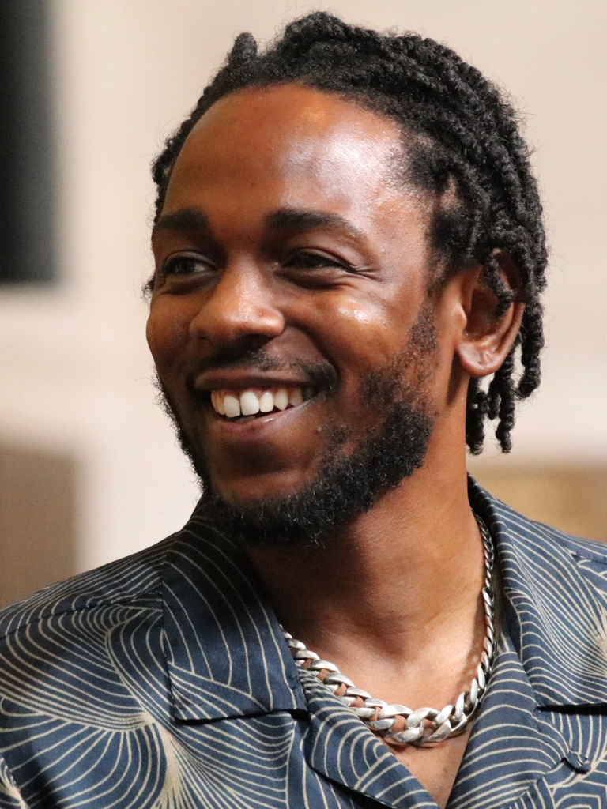

## A bit about Kendrick Lamar

- Compton born American rapper
- One of the most acclaimed artists of his generation
- Known for his outstanding lyricism
- #5 artist on Spotify

### His words - On interview by Ebony, 2019

> “If I can use my platform to carry on a legacy and talk about something that’s real, I have to do that, period”

> — Kendrick Lamar

### His top albums

[figure not shown]

Mr. Morale & The Big Steppers (2022) - DAMN (2017) - good kid, m.A.A.d city (Deluxe) (2012) - To Pimp A Butterfly (2015)

### An iconic song of his - HUMBLE

- >1 billion views on youtube

[HUMBLE (2017, Youtube link)](https://youtu.be/H58vbez_m4E?si=LNX9AnFVFZM01Rn1)

[video not shown]

## Data Analysis

### Data source

My data comes from the artists_2023.zip folder provided by Dr. Joy Lee, from where I downloaded the “Kendrick Lamar.csv” file.

### Import data

```r
library(ggplot2)
library(dplyr)

library(readr)
Kendrick_Lamar <- read_csv("~/LUC/courses/2semester2/data science/DS_Spotify/Spotify_Kendrick/Kendrick Lamar.csv")
View(Kendrick_Lamar)
```

### Take a glance at the data frame

```r
Kendrick_Lamar |> dplyr::slice_sample(n=3) |> knitr::kable(digits = 2)
```

| artist_name | track_name | track_number | album_name | album_release_year | album_release_date | valence | energy | danceability | loudness | tempo | speechiness | instrumentalness | liveness | key_name | mode_name | key_mode | duration_ms |
| --- | --- | --- | --- | --- | --- | --- | --- | --- | --- | --- | --- | --- | --- | --- | --- | --- | --- |
| Kendrick Lamar | FEEL. | 5 | DAMN. | 2017 | 2017-04-14 | 0.55 | 0.80 | 0.75 | -8.38 | 109.97 | 0.35 | 0 | 0.14 | C | major | C major | 214826 |
| Kendrick Lamar | Chapter Ten | 9 | Section.80 | 2011 | 2011-07-02 | 0.54 | 0.74 | 0.52 | -6.39 | 135.77 | 0.22 | 0 | 0.29 | B | minor | B minor | 75535 |
| Kendrick Lamar | Poetic Justice | 6 | good kid, m.A.A.d city (Deluxe) | 2012 | 2012-10-22 | 0.65 | 0.57 | 0.78 | -9.98 | 135.96 | 0.38 | 0 | 0.25 | F# | minor | F# minor | 300160 |

### Data preparation

Since some tracks are duplicated, I have first cleaned them, and then removed live versions and Remixes of the same tracks.

```r
Kendrick_Lamar <- Kendrick_Lamar |> distinct(track_name, .keep_all = TRUE)

Kendrick_Lamar <- Kendrick_Lamar |> filter(!grepl("Live at|Live Acoustic|Remix", track_name))

Kendrick_Lamar$album_name <- as.character(Kendrick_Lamar$album_name)
```

### Album analysis (energy, valence and speechiness)

Since many of his albums are included in the file, I filtered for albums that have the highest number of songs in the data set.

```r
Kendrick_Lamar$album_name <- as.factor(Kendrick_Lamar$album_name)

top_albums <- Kendrick_Lamar %>%
  group_by(album_name) %>%
  summarise(song_count = n()) %>%
  arrange(desc(song_count)) %>%
  slice(1:3)  # Select the top 3 albums

top_albums <- Kendrick_Lamar %>%
  filter(album_name %in% top_albums$album_name)

View(top_albums)
write.csv(top_albums, "top_kendrick_albums.csv", row.names = FALSE)
```

#### Valence level boxsplot

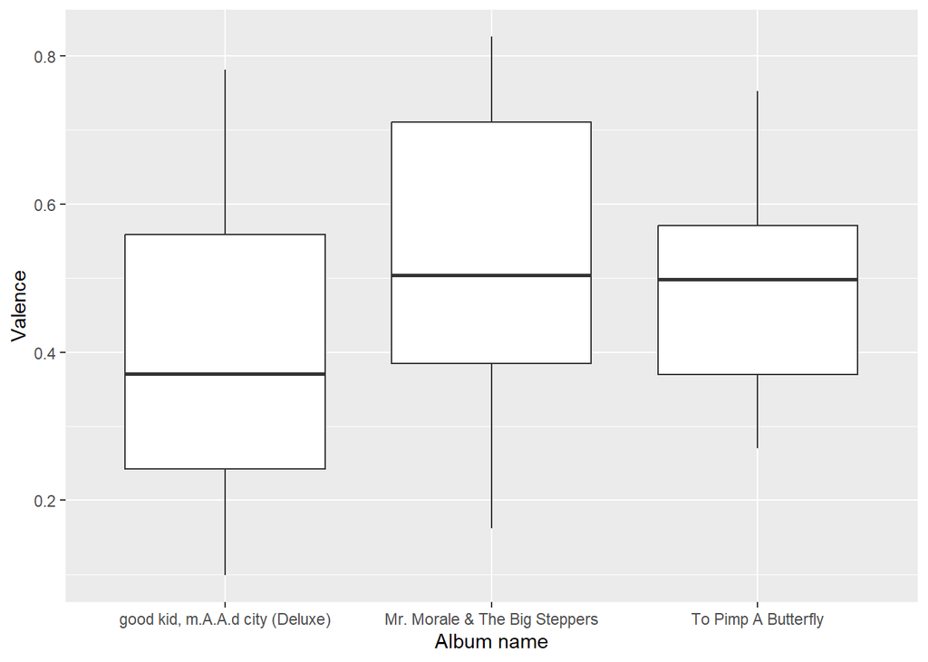

```r
ggplot(top_albums, aes(x=album_name, y=valence))+
  geom_boxplot()+
  labs(x="Album name", y="Valence")
```

The album ‘good kid, m.A.A.d city (Deluxe)’ has the lowest medium for Valence level.

#### Energy level boxsplot

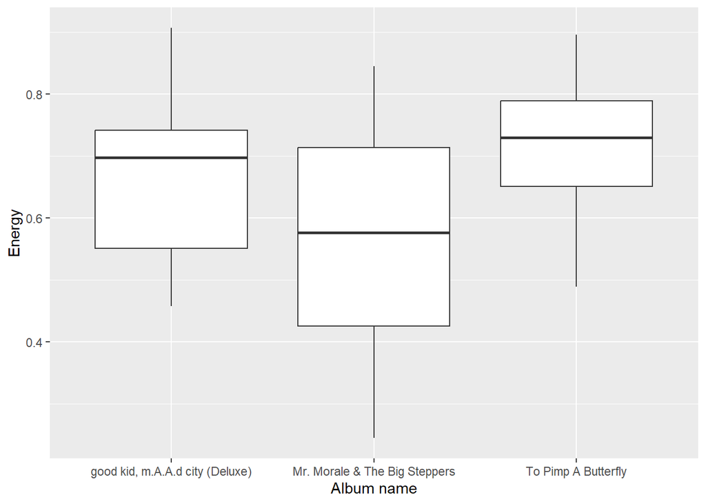

```r
ggplot(top_albums, aes(x=album_name, y=energy))+
  geom_boxplot()+
  labs(x="Album name", y="Energy")
```

But for Energy levels, it has a relatively high medium.

#### Speechiness level boxsplot

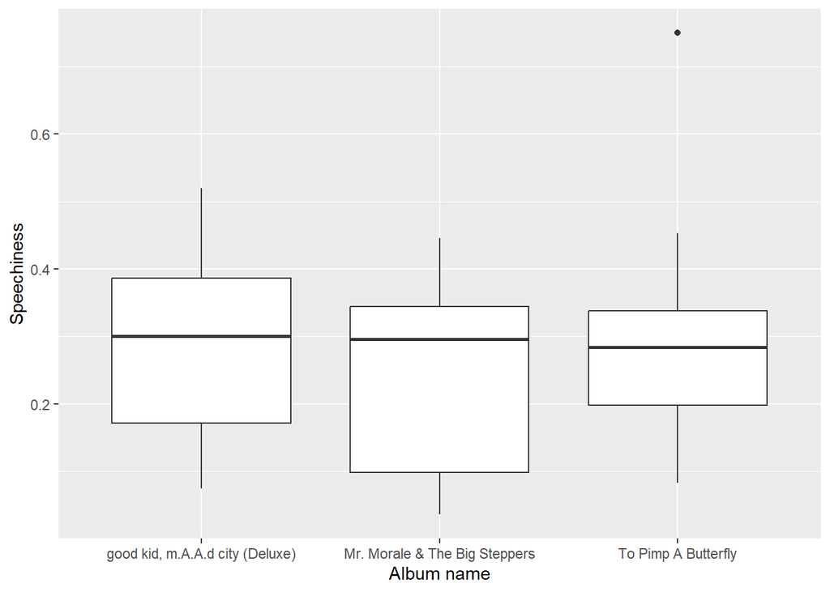

```r
ggplot(top_albums, aes(x=album_name, y=speechiness))+
  geom_boxplot()+
  labs(x="Album name", y="Speechiness")
```

All three albums have low mediums for speechiness level.

### Kendrick Lamar’s most negative song

His top 3 most negative tracks:

```r
Kendrick_Lamar |> slice_min(valence, n=3) |> dplyr::select(track_name, album_name, album_release_year, valence) |> knitr::kable(digits = 2)
```

| track_name | album_name | album_release_year | valence |
| --- | --- | --- | --- |
| untitled 02 \| 06.23.2014. | untitled unmastered. | 2016 | 0.09 |
| Bitch, Don’t Kill My Vibe | good kid, m.A.A.d city (Deluxe) | 2012 | 0.10 |
| untitled 01 \| 08.19.2014. | untitled unmastered. | 2016 | 0.11 |

His top 3 least energetic tracks:

```r
Kendrick_Lamar |> slice_min(energy, n=3) |> dplyr::select(track_name, album_name, album_release_year, energy) |> knitr::kable(digits = 2)
```

| track_name | album_name | album_release_year | energy |
| --- | --- | --- | --- |
| untitled 04 \| 08.14.2014. | untitled unmastered. | 2016 | 0.13 |
| BLOOD. | DAMN. COLLECTORS EDITION. | 2017 | 0.24 |
| Crown | Mr. Morale & The Big Steppers | 2022 | 0.24 |

His top 3 tracks with the smallest presence of spoken words:

```r
Kendrick_Lamar |> slice_min(speechiness, n=3) |> dplyr::select(track_name, album_name, album_release_year, speechiness) |> knitr::kable(digits = 2)
```

| track_name | album_name | album_release_year | speechiness |
| --- | --- | --- | --- |
| Crown | Mr. Morale & The Big Steppers | 2022 | 0.04 |
| Alien Girl (Today W/ Her) | Overly Dedicated | 2010 | 0.04 |
| untitled 06 \| 06.30.2014. | untitled unmastered. | 2016 | 0.05 |

[Crown (2022, Youtube link](https://youtu.be/maFB3xElO8g?si=ck4_kljIK-UqlRBQ)

[video not shown]

About ‘Crown’ :

- his contrasting feelings about being seen and doing his best as a leader in his community while – obviously – not being able to please everyone
- the crown imagery on the album’s cover where Kendrick – a Christian himself – wears a crown of thorn, a key symbols of Jesus Christ

#### References:

- https://open.spotify.com/artist/2YZyLoL8N0Wb9xBt1NhZWg
- https://www.ebony.com/kendrick-talks-politics-spirituality-music-more-333/#axzz4LiQrTAXX
- https://genius.com/Kendrick-lamar-crown-lyrics